# PROJECT 2

GOODNESS NWOKEBU

## 1.0: Load the data

```r
#Sample code to import the dataset in R
yengoHeight <- "https://raw.githubusercontent.com/HackBio-Internship/public_datasets/main/R/datasets/Contests/humanGeneticVariationsSamples.tsv"
yengoHeight <- read.table(yengoHeight)
head(yengoHeight)
```

|  | SNPID | RSID | CHR | POS | EFFECT_ALLELE | OTHER_ALLELE | EFFECT_ALLELE_FREQ | BETA | SE | P | N | ANCESTRY |
| --- | --- | --- | --- | --- | --- | --- | --- | --- | --- | --- | --- | --- |
| 15885 | 1:32296525:C:T | rs4949473 | 1 | 32296525 | C | T | 0.299 | -0.00311101 | 0.00496 | 0.530811 | 100692 | AFRICAN |
| 23949 | 1:49121231:A:G | rs319993 | 1 | 49121231 | A | G | 0.686 | -0.00340862 | 0.00492 | 0.488601 | 104293 | AFRICAN |
| 73516 | 1:171155103:C:T | rs6657314 | 1 | 171155103 | T | C | 0.852 | -0.00436463 | 0.00644 | 0.497941 | 104294 | AFRICAN |
| 77457 | 1:179183766:C:T | rs2816213 | 1 | 179183766 | C | T | 0.263 | -0.00788237 | 0.00534 | 0.139673 | 104294 | AFRICAN |
| 15298 | 1:31139078:A:C | rs1983822 | 1 | 31139078 | C | A | 0.578 | -0.00764437 | 0.00480 | 0.111489 | 104294 | AFRICAN |
| 67183 | 1:161014649:A:G | rs1556259 | 1 | 161014649 | G | A | 0.547 | 0.00483336 | 0.00466 | 0.300028 | 100692 | AFRICAN |

```r
class(yengoHeight)
```

```
[1] "data.frame"
```

```r
##Data Preprocessing

summary(yengoHeight)
```

```
    SNPID               RSID               CHR                 POS
 Length:24806       Length:24806       Length:24806       Min.   :    67365
 Class :character   Class :character   Class :character   1st Qu.: 31782304
 Mode  :character   Mode  :character   Mode  :character   Median : 71128448
                                                          Mean   : 79520031
                                                          3rd Qu.:115715089
                                                          Max.   :249222450
 EFFECT_ALLELE      OTHER_ALLELE       EFFECT_ALLELE_FREQ      BETA
 Length:24806       Length:24806       Min.   :0.000017   Min.   :-1.5380600
 Class :character   Class :character   1st Qu.:0.095425   1st Qu.:-0.0053944
 Mode  :character   Mode  :character   Median :0.270000   Median :-0.0000528
                                       Mean   :0.341546   Mean   : 0.0002959
                                       3rd Qu.:0.549750   3rd Qu.: 0.0051544
                                       Max.   :1.000000   Max.   : 1.9348500
       SE                P                N             ANCESTRY
 Min.   :0.00104   Min.   :0.0000   Min.   :    482   Length:24806
 1st Qu.:0.00358   1st Qu.:0.1163   1st Qu.:  53717   Class :character
 Median :0.00654   Median :0.3729   Median : 100692   Mode  :character
 Mean   :0.01802   Mean   :0.4087   Mean   : 377682
 3rd Qu.:0.00944   3rd Qu.:0.6742   3rd Qu.: 264725
 Max.   :1.07000   Max.   :0.9999   Max.   :1597374
     CHRI
 Length:24806
 Class :character
 Mode  :character
```

## 1.1 Data Cleaning

```r
# Removing Null set
yengoHeight <- na.omit(yengoHeight)
#inappropriate data types
yengoHeight$CHR <- as.character(yengoHeight$CHR)
```

## 1.2 Data Visualisation

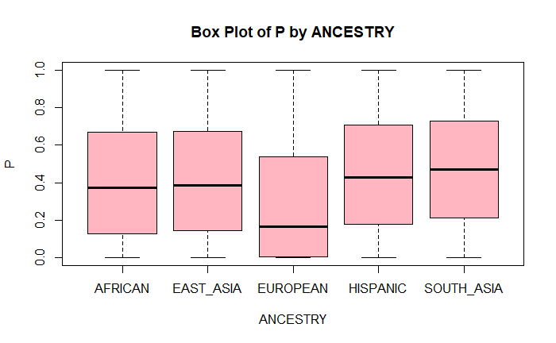

```r
boxplot(P ~ ANCESTRY, data = yengoHeight, col = 'lightpink',
        main = "Box Plot of P by ANCESTRY", xlab = "ANCESTRY", ylab = "P")
```

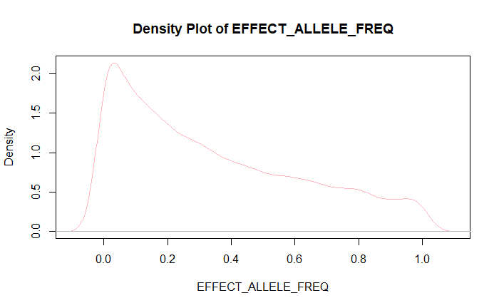

```r
plot(density(yengoHeight$EFFECT_ALLELE_FREQ), col = "lightpink", main = "Density Plot of EFFECT_ALLELE_FREQ", xlab = "EFFECT_ALLELE_FREQ")
```

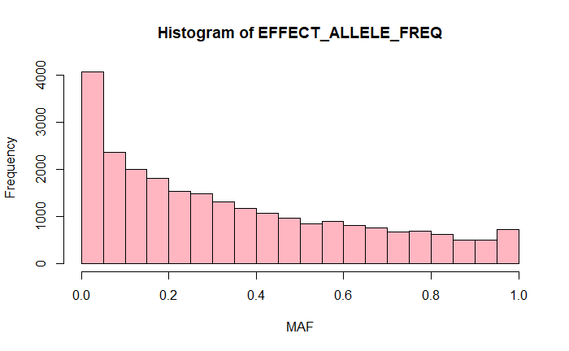

```r
hist(yengoHeight$EFFECT_ALLELE_FREQ, xlab = 'MAF', ylab = 'Frequency', col = 'lightpink', main = "Histogram of EFFECT_ALLELE_FREQ")
```

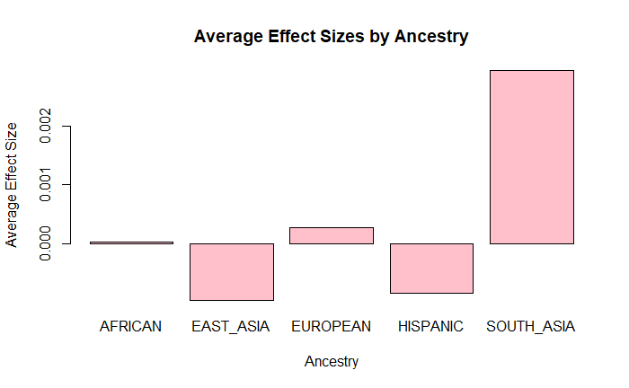

```r
# Calculate average effect sizes for each SNP, stratified by ancestry
average_effect_sizes <- aggregate(yengoHeight$BETA ~ yengoHeight$ANCESTRY, FUN = mean)

# Create a bar plot of average effect sizes by ancestry
barplot(average_effect_sizes[, 2], names.arg = average_effect_sizes[, 1], col = "pink",
        main = "Average Effect Sizes by Ancestry", xlab = "Ancestry", ylab = "Average Effect Size")
```

```r
NA
NA
```

## 1.3 Data Analysis

### Question 1

##### How many SNPs are significant (p-value < 0.01) for variability in height (MAF > 0.01) in all the super populations.

```r
# Step 1: Filter the data based on the conditions
filtered_snps <- yengoHeight[yengoHeight$P < 0.01 & yengoHeight$EFFECT_ALLELE_FREQ > 0.01, ]

# Step 2: Count the number of SNPs that satisfy the conditions in step1
num_significant_snps <- nrow(filtered_snps)


print(paste("The number of significant SNPs for variability in height (P-value < 0.01 and MAF > 0.01) in all super populations is:", num_significant_snps))
```

```
[1] "The number of significant SNPs for variability in height (P-value < 0.01 and MAF > 0.01) in all super populations is: 2253"
```

#### what five Chromosomes should we look out for significant SNPs ?

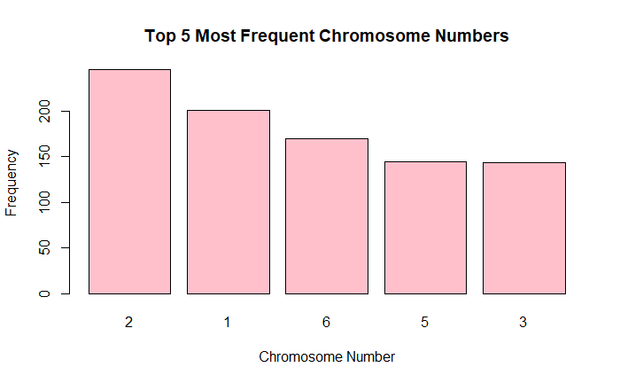

```r
# Find the chromosome number that is most frequent
chromosome_counts <- table(filtered_snps$CHR)



# Sort the chromosome counts in descending order and select the top 5 values
top_chromosomes <- head(sort(chromosome_counts, decreasing = TRUE), 5)

# Create a bar plot for the top 5 most frequent chromosome numbers
barplot(top_chromosomes, main = "Top 5 Most Frequent Chromosome Numbers",
        xlab = "Chromosome Number", ylab = "Frequency", col = "pink")
```

```r
NA
NA
NA
```

Chromosomes 2, 1,6,5,3 is shown to be the top chromosomes that genetic variation occurs.

### Which ancestry have the most signiicant genetic variability?

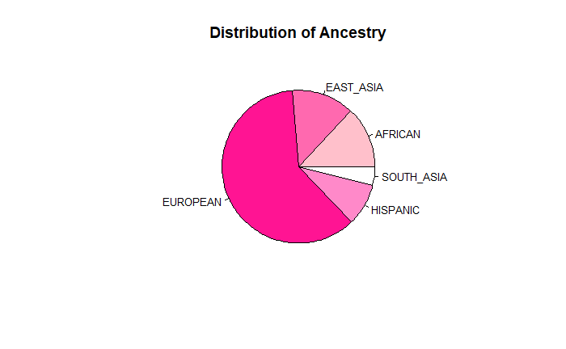

```r
# Calculate the frequency of each unique value in the 'ANCESTRY' column
ancestry_counts <- table(filtered_snps$ANCESTRY)
most_common_ancestry <- names(ancestry_counts)[which.max(ancestry_counts)]




num_ancestries <- length(ancestry_counts)
custom_palette <- colorRampPalette(c("pink","deeppink", "white"))(num_ancestries)
pie(ancestry_counts, main = "Distribution of Ancestry", col = custom_palette, labels = names(ancestry_counts), cex = 0.8)
```

## Question 2

#### How much of Europeans genetic variability can/cannot be found in other super populations.

The question about the proportion of European genetic variability that can or cannot be found in other super populations raises points is related to population genetics and the significance of diversity in sequencing projects.

Defining a Null Hypothesis will help with that:

Null Hypothesis: The genetic variability observed in the European population is not significantly different from the genetic variability observed in other super populations.

To investigate this question, a Chi square statistical test will be used for the analysis.

```r
european_data <- filtered_snps[yengoHeight$ANCESTRY == 'European', ]
european_variability <- sum(european_data$EFFECT_ALLELE_FREQ)

# Calculate the observed genetic variability in other super populations
other_data <- yengoHeight[yengoHeight$ANCESTRY != 'European', ]
other_variability <- sum(other_data$EFFECT_ALLELE_FREQ)

# Perform a chi-squared test
chisq_result <- chisq.test(c(european_variability, other_variability))
print(chisq_result)
```

```
    Chi-squared test for given probabilities

data:  c(european_variability, other_variability)
X-squared = 8472.4, df = 1, p-value < 2.2e-16
```